# Your Title

### 3.4 Cohort Scoping and EDA

Following guidance from Dr. Lindsey George to ensure rigorous and focused cohort scoping, we restrict our dataset to interventional studies explicitly evaluating AAV vector gene therapies. We conduct exploratory data analysis (EDA) to verify sample size adequacy (N) across trial phases and enrollment years before text extraction.

```r
# 1. Overall cohort size and enrollment (N) summary across aav_master_df
cohort_overview <- aav_master_df %>%
  summarise(
    total_trials = n(),
    total_participants_n = sum(enrollment, na.rm = TRUE),
    median_enrollment = median(enrollment, na.rm = TRUE),
    iqr_enrollment = IQR(enrollment, na.rm = TRUE),
    min_enrollment = min(enrollment, na.rm = TRUE),
    max_enrollment = max(enrollment, na.rm = TRUE),
    missing_enrollment = sum(is.na(enrollment))
  )

print(cohort_overview)
```

```
# A tibble: 1 × 7
  total_trials total_participants_n median_enrollment iqr_enrollment
         <int>                <dbl>             <dbl>          <dbl>
1          530                20962              13.5             22
# ℹ 3 more variables: min_enrollment <dbl>, max_enrollment <dbl>,
#   missing_enrollment <int>
```

```r
# 2. Trial count and participant enrollment (N) across trial phases
phase_summary <- aav_master_df %>%
  mutate(phase = if_else(is.na(phase) | phase == "", "Not Specified / NA", phase)) %>%
  group_by(phase) %>%
  summarise(
    n_trials = n(),
    pct_trials = round(n() / nrow(aav_master_df) * 100, 1),
    total_participants = sum(enrollment, na.rm = TRUE),
    median_participants = median(enrollment, na.rm = TRUE),
    .groups = "drop"
  ) %>%
  arrange(desc(n_trials))

print(phase_summary)
```

```
# A tibble: 8 × 5
  phase              n_trials pct_trials total_participants median_participants
  <chr>                 <int>      <dbl>              <dbl>               <dbl>
1 PHASE1/PHASE2           219       41.3               4693                13
2 PHASE1                  121       22.8               1663                10
3 PHASE3                   53       10                 4322                39
4 PHASE2                   48        9.1               3958                26.5
5 EARLY_PHASE1             44        8.3                410                 8.5
6 Not Specified / NA       27        5.1               3975                12
7 PHASE2/PHASE3            17        3.2               1921                55
8 PHASE4                    1        0.2                 20                20
```

```r
# 3. Trial counts and enrollment by start/enrollment year
year_summary <- aav_master_df %>%
  mutate(start_year = year(as.Date(start_date))) %>%
  filter(!is.na(start_year)) %>%
  group_by(start_year) %>%
  summarise(
    n_trials = n(),
    total_participants = sum(enrollment, na.rm = TRUE),
    .groups = "drop"
  ) %>%
  arrange(start_year)

print(year_summary, n = Inf)
```

```
# A tibble: 26 × 3
   start_year n_trials total_participants
        <dbl>    <int>              <dbl>
 1       1999        1                 19
 2       2003        3                192
 3       2004        6                 72
 4       2005        3                223
 5       2006        4                 82
 6       2007        5                104
 7       2008        4                124
 8       2009        4                 77
 9       2010        8                113
10       2011        6                 82
11       2012        6                338
12       2013        6                 88
13       2014        8                112
14       2015       17                178
15       2016       15                334
16       2017       32               1049
17       2018       33               1399
18       2019       24               1323
19       2020       29               4289
20       2021       33                909
21       2022       35               1574
22       2023       70               2325
23       2024       63               2082
24       2025       55               1403
25       2026       53               2199
26       2027        7                272
```

```r
# 4. Lead sponsor agency class breakdown
sponsor_summary <- aav_master_df %>%
  mutate(
    lead_agency_class = if_else(
      is.na(lead_agency_class) | lead_agency_class == "",
      "Not Specified / NA",
      lead_agency_class
    )
  ) %>%
  group_by(lead_agency_class) %>%
  summarise(
    n_trials = n(),
    pct_trials = round(n() / nrow(aav_master_df) * 100, 1),
    total_participants = sum(enrollment, na.rm = TRUE),
    .groups = "drop"
  ) %>%
  arrange(desc(n_trials))

print(sponsor_summary)
```

```
# A tibble: 5 × 4
  lead_agency_class n_trials pct_trials total_participants
  <chr>                <int>      <dbl>              <dbl>
1 INDUSTRY               373       70.4              15123
2 OTHER                  140       26.4               4957
3 NETWORK                  8        1.5                629
4 NIH                      5        0.9                122
5 OTHER_GOV                4        0.8                131
```

Now that we’ve got the numbers, let’s do some visualization! Here, I am going to create a chart that shows trial counts by phase on the left, and trial starts over time (by enrollment/start year) on the right.

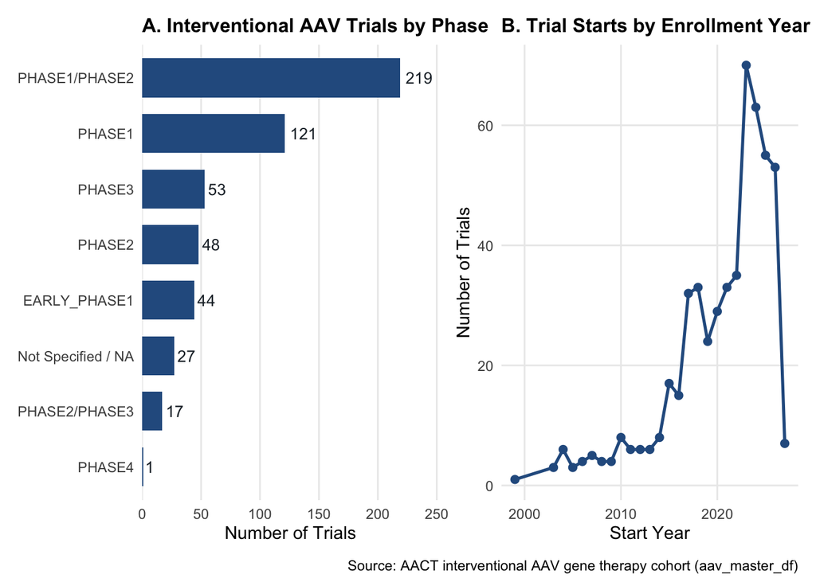

```r
# Prepare phase ordering and clean labels
phase_plot_df <- aav_master_df %>%
  mutate(
    phase_clean = if_else(is.na(phase) | phase == "", "Not Specified / NA", phase)
  ) %>%
  count(phase_clean, name = "n_trials") %>%
  mutate(phase_clean = fct_reorder(phase_clean, n_trials))

# Panel A: Trial count by clinical phase
p_phase <- ggplot(phase_plot_df, aes(x = phase_clean, y = n_trials)) +
  geom_col(fill = "#2B5C8F", width = 0.7) +
  geom_text(aes(label = n_trials), hjust = -0.2, size = 3.5, color = "#1F2933") +
  coord_flip() +
  scale_y_continuous(expand = expansion(mult = c(0, 0.15))) +
  labs(
    title = "A. Interventional AAV Trials by Phase",
    x = NULL,
    y = "Number of Trials"
  ) +
  theme_minimal(base_size = 11) +
  theme(
    panel.grid.minor = element_blank(),
    panel.grid.major.y = element_blank(),
    plot.title = element_text(face = "bold", size = 12)
  )

# Prepare annual trial counts by start year
year_plot_df <- aav_master_df %>%
  mutate(start_year = year(as.Date(start_date))) %>%
  filter(!is.na(start_year)) %>%
  count(start_year, name = "n_trials")

# Panel B: Trial starts over time
p_year <- ggplot(year_plot_df, aes(x = start_year, y = n_trials)) +
  geom_line(color = "#2B5C8F", linewidth = 0.9) +
  geom_point(color = "#2B5C8F", size = 2) +
  labs(
    title = "B. Trial Starts by Enrollment Year",
    x = "Start Year",
    y = "Number of Trials"
  ) +
  theme_minimal(base_size = 11) +
  theme(
    panel.grid.minor = element_blank(),
    plot.title = element_text(face = "bold", size = 12)
  )

# Combine side by side
p_phase + p_year +
  plot_annotation(
    caption = "Source: AACT interventional AAV gene therapy cohort (aav_master_df)"
  )
```

### 3.5 Regex-Based NLP Pipeline

To build our regex-based pipeline as a baseline before we benchmark an LLM pipeline, we start on section segmentation of critera text (inclusion vs exclusion). Below, we split the unstructured criteria text from our master dataframe to create separate fields so polarity (e.g. requiring seronegativity vs excluding seropositivity) can be evaluated properly.

```r
# Split unstructured criteria text into Inclusion and Exclusion blocks
aav_nlp_prep <- aav_master_df %>%
  mutate(
    # Normalize line breaks and whitespace artifacts
    criteria_clean = str_replace_all(criteria, "\\r\\n|\\r", "\n"),

    # Extract Inclusion block (everything before Exclusion Criteria header)
    inclusion_text = case_when(
      str_detect(criteria_clean, regex("exclusion criteria\\s*:?", ignore_case = TRUE)) ~
        str_extract(criteria_clean, regex("(?s).*?(?=exclusion criteria\\s*:?)", ignore_case = TRUE)),
      TRUE ~ criteria_clean
    ),

    # Extract Exclusion block (everything from Exclusion Criteria header onward)
    exclusion_text = if_else(
      str_detect(criteria_clean, regex("exclusion criteria\\s*:?", ignore_case = TRUE)),
      str_extract(criteria_clean, regex("(?s)exclusion criteria\\s*:?.*", ignore_case = TRUE)),
      NA_character_
    )
  )
```

Starting from aav_nlp_prep, we’ll split on newlines, ~ delimiters, numbered items, and bullet markers to keep individual rules granular while filtering down to lines referencing antibodies, serostatus, or titers.

```r
# Broad recall dictionary for anti-AAV humoral immunity mentions
ab_mention_regex <- regex(
  paste0(
    "\\b(",
    "antibod(y|ies)|nab|nabs|tab|tabs|igg|igm|",
    "seropositiv(e|ity)|seronegativ(e|ity)|serostatus|serolog(y|ic|ical)|",
    "titer(s)?|titre(s)?|neutraliz(ing|ation)|neutralis(ing|ation)|",
    "binding antibod(y|ies)|pre[- ]?existing immunit(y|ies)|elisa|luminex",
    ")\\b"
  ),
  ignore_case = TRUE
)

# Expand to 1 row per criterion clause and isolate antibody-relevant lines
antibody_clauses_v2 <- aav_nlp_prep %>%
  select(nct_id, phase, lead_agency_class, start_date, enrollment, inclusion_text, exclusion_text) %>%
  pivot_longer(
    cols = c(inclusion_text, exclusion_text),
    names_to = "section",
    values_to = "section_text"
  ) %>%
  mutate(section = str_remove(section, "_text")) %>%
  filter(!is.na(section_text)) %>%
  separate_rows(
    section_text,
    sep = "\\n+|~+|\\s+(?=[0-9]{1,2}\\.\\s)|\\s*[•\\*\\-]\\s+(?=[A-Z0-9])"
  ) %>%
  mutate(clause = str_squish(section_text)) %>%
  filter(nchar(clause) > 5) %>%
  filter(str_detect(clause, ab_mention_regex))
```

Broad antibody matching will pull in non-AAV clinical criteria, so the below code will drop clauses matching known non-AAV serology or inhibitor terms unless the clause also explicitly anchors to an AAV vector, capsid, or transgene.

```r
non_aav_ab_regex <- regex(
  "\\b(hiv|hepatitis\\s*[a-e]|hbv|hcv|hav|cmv|ebv|hsv|sars-cov-2|covid|factor\\s*(viii|ix|8|9)|fix|fviii|inhibitor|anti-drug)\\b",
  ignore_case = TRUE
)

vector_anchor_regex <- regex(
  "\\b((r|sc)?aav[- ]?(rh)?[0-9a-z]*|adeno[- ]associated|vector|capsid|transgene)\\b",
  ignore_case = TRUE
)

antibody_clauses_filtered <- antibody_clauses_v2 %>%
  mutate(
    has_vector_anchor = str_detect(clause, vector_anchor_regex),
    is_non_aav_noise  = str_detect(clause, non_aav_ab_regex)
  ) %>%
  filter(has_vector_anchor | !is_non_aav_noise)
```

Now that we have isolated to individual antibody-related clauses, deterministic regular expressions can extract our 4 core clinical eligibility parameters:

- **Target Serotype -** e.g. AAV9, AAVrh74, AAV5, AAV8, AAV2
- **Titer/Cutoff Threshold -** e.g. 1:5, 1:50, < 1:10, >= 1:100, or OD/units
- **Assay Methodology** - NAb neutralizing assay vs TAb total binding
- **Eligibility Rule Direction** - does the clause enforce a seronegative requirement or an exclusion cutoff?

```r
regex_baseline_clauses <- antibody_clauses_filtered %>%
  mutate(
    extracted_serotype = str_extract_all(
      clause,
      regex("\\b(r|sc)?aav[- ]?(rh)?[0-9]{1,2}[a-z0-9]*\\b", ignore_case = TRUE)
    ) %>% map_chr(~ paste(unique(toupper(.x)), collapse = "; ")),
    extracted_serotype = na_if(extracted_serotype, ""),

    extracted_titer = str_extract_all(
      clause,
      regex(
        "([<>≤≥]=?\\s*)?1\\s*:\\s*[0-9,]+|[<>≤≥]=?\\s*[0-9]+(\\.[0-9]+)?\\s*(u/ml|iu/ml|ng/ml|od)",
        ignore_case = TRUE
      )
    ) %>% map_chr(~ paste(unique(.x), collapse = "; ")),
    extracted_titer = na_if(extracted_titer, ""),

    extracted_assay = case_when(
      str_detect(clause, regex("neutraliz|neutralis|\\bnab(s)?\\b", ignore_case = TRUE)) &
        str_detect(clause, regex("binding|\\btab(s)?\\b|elisa|eclia|meso scale", ignore_case = TRUE)) ~ "Both (NAb & TAb)",
      str_detect(clause, regex("neutraliz|neutralis|\\bnab(s)?\\b", ignore_case = TRUE)) ~ "Neutralizing Antibody (NAb)",
      str_detect(clause, regex("binding|\\btab(s)?\\b|elisa|eclia|meso scale|igg", ignore_case = TRUE)) ~ "Total Binding Antibody (TAb)",
      TRUE ~ "Unspecified Serology"
    ),

    has_numeric_cutoff = !is.na(extracted_titer)
  )

# Clause-level summary counts
regex_baseline_clauses %>%
  summarise(
    total_clauses = n(),
    unique_trials = n_distinct(nct_id),
    clauses_with_serotype = sum(!is.na(extracted_serotype)),
    clauses_with_titer = sum(!is.na(extracted_titer))
  )
```

```
# A tibble: 1 × 4
  total_clauses unique_trials clauses_with_serotype clauses_with_titer
          <int>         <int>                 <int>              <int>
1           272           228                   161                127
```

```r
# Breakdown by assay type across filtered clauses
regex_baseline_clauses %>%
  count(extracted_assay, sort = TRUE)
```

```
# A tibble: 4 × 2
  extracted_assay                  n
  <chr>                        <int>
1 Neutralizing Antibody (NAb)    114
2 Unspecified Serology           104
3 Total Binding Antibody (TAb)    43
4 Both (NAb & TAb)                11
```

Now, because a single trial may contain multiple antibody clauses across inclusion and exclusion criteria, we will roll the extracted clauses back up to the nct_id level and merge them onto aav_master_df so each trial in our cohort is labeled as having or lacking anti-AAV antibody restrictions.

```r
trial_ab_summary <- regex_baseline_clauses %>%
  group_by(nct_id) %>%
  summarise(
    has_ab_criteria = TRUE,
    ab_sections = paste(unique(section), collapse = "; "),
    serotypes_mentioned = paste(unique(na.omit(extracted_serotype)), collapse = "; "),
    titer_cutoffs = paste(unique(na.omit(extracted_titer)), collapse = "; "),
    assay_types = paste(unique(extracted_assay), collapse = "; "),
    has_numeric_cutoff = any(has_numeric_cutoff),
    matched_clauses = paste(clause, collapse = " || "),
    .groups = "drop"
  ) %>%
  mutate(
    serotypes_mentioned = na_if(serotypes_mentioned, ""),
    titer_cutoffs = na_if(titer_cutoffs, "")
  )

aav_baseline_results <- aav_master_df %>%
  left_join(trial_ab_summary, by = "nct_id") %>%
  mutate(has_ab_criteria = replace_na(has_ab_criteria, FALSE))

# Trial-level baseline counts
aav_baseline_results %>%
  summarise(
    total_trials = n(),
    trials_with_ab_criteria = sum(has_ab_criteria),
    pct_with_ab_criteria = round(mean(has_ab_criteria) * 100, 1),
    trials_with_numeric_titer = sum(has_numeric_cutoff, na.rm = TRUE)
  )
```

```
# A tibble: 1 × 4
  total_trials trials_with_ab_criteria pct_with_ab_criteria
         <int>                   <int>                <dbl>
1          530                     228                   43
# ℹ 1 more variable: trials_with_numeric_titer <int>
```

### 3.6 Regex Analysis: Correlates of Antibody Critera & Titer Cutoffs

The below code builds on our trial-level baseline results and clauses to summarize patterns across:

- **Lead sponsor class** - Industry vs NIH, Other, etc
- **Broad indication/therapeutic area** - Grouped via keyword buckets from conditions table
- **Enrollment/start year** - Both annual trends and pre-/post-2020 or era comparisons
- **Trial phase** - Phase 1, Phase 2, Phase 1/2, Phase 3…

```r
# --- STEP 1: Add derived trial covariates (start year, era, broad indication) ---
aav_analysis_df <- aav_baseline_results %>%
  mutate(
    start_year = year(as.Date(start_date)),
    trial_era = case_when(
      is.na(start_year) ~ "Unknown",
      start_year < 2018 ~ "Pre-2018",
      start_year <= 2021 ~ "2018–2021",
      TRUE ~ "2022–Present"
    ),
    phase_clean = if_else(is.na(phase) | phase == "", "Unspecified / NA", phase),
    sponsor_clean = if_else(
      is.na(lead_agency_class) | lead_agency_class == "",
      "Unspecified / NA",
      lead_agency_class
    ),
    # Broad clinical indication grouping from collapsed conditions string
    indication_group = case_when(
      str_detect(conditions, regex("muscular dystrophy|duchenne|becker|myopathy|charcot-marie|pompe|als|amyotrophic", ignore_case = TRUE)) ~ "Neuromuscular / Motor",
      str_detect(conditions, regex("hemophilia|factor viii|factor ix|von willebrand|bleeding", ignore_case = TRUE)) ~ "Hematology / Coagulation",
      str_detect(conditions, regex("retinal|retinitis|macular|leber|glaucoma|choroideremia|optic|ocular|eye", ignore_case = TRUE)) ~ "Ophthalmology",
      str_detect(conditions, regex("parkinson|alzheimer|huntington|epilepsy|dravet|rett|angelman|batten|cns|neuro", ignore_case = TRUE)) ~ "CNS / Neurodegenerative",
      str_detect(conditions, regex("fabry|gaucher|mucopolysaccharidosis|mps|phenylketonuria|pku|glycogen|metabolic|liver|hepatic|hypercholesterolemia", ignore_case = TRUE)) ~ "Metabolic / Hepatic",
      str_detect(conditions, regex("heart failure|cardiomyopathy|arrhythmia|cardiac|tachycardia", ignore_case = TRUE)) ~ "Cardiovascular",
      TRUE ~ "Other / Multi-System"
    )
  )

# --- STEP 2: Antibody & numeric-titer prevalence by Lead Sponsor Class ---
sponsor_ab_summary <- aav_analysis_df %>%
  group_by(sponsor_clean) %>%
  summarise(
    n_trials = n(),
    n_with_ab = sum(has_ab_criteria),
    pct_with_ab = round(mean(has_ab_criteria) * 100, 1),
    n_with_titer = sum(has_numeric_cutoff, na.rm = TRUE),
    pct_with_titer_among_ab = round(
      if_else(n_with_ab > 0, n_with_titer / n_with_ab * 100, NA_real_), 1
    ),
    median_enrollment = median(enrollment, na.rm = TRUE),
    .groups = "drop"
  ) %>%
  arrange(desc(n_trials))

print(sponsor_ab_summary)
```

```
# A tibble: 5 × 7
  sponsor_clean n_trials n_with_ab pct_with_ab n_with_titer
  <chr>            <int>     <int>       <dbl>        <int>
1 INDUSTRY           373       150        40.2           65
2 OTHER              140        72        51.4           47
3 NETWORK              8         2        25              1
4 NIH                  5         3        60              2
5 OTHER_GOV            4         1        25              0
# ℹ 2 more variables: pct_with_titer_among_ab <dbl>, median_enrollment <dbl>
```

```r
# --- STEP 3: Antibody prevalence by Therapeutic Indication ---
indication_ab_summary <- aav_analysis_df %>%
  group_by(indication_group) %>%
  summarise(
    n_trials = n(),
    n_with_ab = sum(has_ab_criteria),
    pct_with_ab = round(mean(has_ab_criteria) * 100, 1),
    n_with_titer = sum(has_numeric_cutoff, na.rm = TRUE),
    pct_with_titer_among_ab = round(
      if_else(n_with_ab > 0, n_with_titer / n_with_ab * 100, NA_real_), 1
    ),
    .groups = "drop"
  ) %>%
  arrange(desc(n_trials))

print(indication_ab_summary)
```

```
# A tibble: 7 × 6
  indication_group         n_trials n_with_ab pct_with_ab n_with_titer
  <chr>                       <int>     <int>       <dbl>        <int>
1 Other / Multi-System          183        78        42.6           43
2 Ophthalmology                 111         9         8.1            6
3 Neuromuscular / Motor          70        50        71.4           30
4 CNS / Neurodegenerative        59        17        28.8           10
5 Hematology / Coagulation       56        43        76.8           13
6 Metabolic / Hepatic            45        29        64.4           12
7 Cardiovascular                  6         2        33.3            1
# ℹ 1 more variable: pct_with_titer_among_ab <dbl>
```

```r
# --- STEP 4: Antibody prevalence by Start Year & Trial Era ---
year_ab_summary <- aav_analysis_df %>%
  filter(!is.na(start_year)) %>%
  group_by(start_year) %>%
  summarise(
    n_trials = n(),
    n_with_ab = sum(has_ab_criteria),
    pct_with_ab = round(mean(has_ab_criteria) * 100, 1),
    n_with_titer = sum(has_numeric_cutoff, na.rm = TRUE),
    .groups = "drop"
  ) %>%
  arrange(start_year)

print(year_ab_summary, n = Inf)
```

```
# A tibble: 26 × 5
   start_year n_trials n_with_ab pct_with_ab n_with_titer
        <dbl>    <int>     <int>       <dbl>        <int>
 1       1999        1         0         0              0
 2       2003        3         0         0              0
 3       2004        6         4        66.7            1
 4       2005        3         0         0              0
 5       2006        4         1        25              0
 6       2007        5         3        60              2
 7       2008        4         0         0              0
 8       2009        4         0         0              0
 9       2010        8         2        25              0
10       2011        6         0         0              0
11       2012        6         4        66.7            3
12       2013        6         4        66.7            2
13       2014        8         5        62.5            1
14       2015       17         9        52.9            5
15       2016       15         7        46.7            5
16       2017       32        20        62.5            7
17       2018       33        12        36.4            6
18       2019       24        14        58.3            7
19       2020       29         9        31              3
20       2021       33        12        36.4            3
21       2022       35        16        45.7            7
22       2023       70        31        44.3           20
23       2024       63        28        44.4           17
24       2025       55        27        49.1           16
25       2026       53        15        28.3            6
26       2027        7         5        71.4            4
```

```r
era_ab_summary <- aav_analysis_df %>%
  group_by(trial_era) %>%
  summarise(
    n_trials = n(),
    n_with_ab = sum(has_ab_criteria),
    pct_with_ab = round(mean(has_ab_criteria) * 100, 1),
    n_with_titer = sum(has_numeric_cutoff, na.rm = TRUE),
    .groups = "drop"
  )

print(era_ab_summary)
```

```
# A tibble: 3 × 5
  trial_era    n_trials n_with_ab pct_with_ab n_with_titer
  <chr>           <int>     <int>       <dbl>        <int>
1 2018–2021         119        47        39.5           19
2 2022–Present      283       122        43.1           70
3 Pre-2018          128        59        46.1           26
```

```r
# --- STEP 5: Antibody prevalence by Trial Phase ---
phase_ab_summary <- aav_analysis_df %>%
  group_by(phase_clean) %>%
  summarise(
    n_trials = n(),
    n_with_ab = sum(has_ab_criteria),
    pct_with_ab = round(mean(has_ab_criteria) * 100, 1),
    n_with_titer = sum(has_numeric_cutoff, na.rm = TRUE),
    .groups = "drop"
  ) %>%
  arrange(desc(n_trials))

print(phase_ab_summary)
```

```
# A tibble: 8 × 5
  phase_clean      n_trials n_with_ab pct_with_ab n_with_titer
  <chr>               <int>     <int>       <dbl>        <int>
1 PHASE1/PHASE2         219       104        47.5           52
2 PHASE1                121        54        44.6           26
3 PHASE3                 53        21        39.6            7
4 PHASE2                 48        10        20.8            3
5 EARLY_PHASE1           44        23        52.3           16
6 Unspecified / NA       27         9        33.3            8
7 PHASE2/PHASE3          17         6        35.3            3
8 PHASE4                  1         1       100              0
```

```r
# --- STEP 6: Simple statistical association checks (Chi-square / Fisher's exact) ---
# Sponsor vs. presence of antibody criteria
sponsor_tab <- aav_analysis_df %>%
  filter(sponsor_clean %in% c("INDUSTRY", "OTHER", "NIH")) %>%
  with(table(sponsor_clean, has_ab_criteria))

print(chisq.test(sponsor_tab))
```

```
    Pearson's Chi-squared test

data:  sponsor_tab
X-squared = 5.774, df = 2, p-value = 0.05574
```

```r
# Indication vs. presence of antibody criteria (Fisher's exact handles smaller cell counts)
indication_tab <- with(aav_analysis_df, table(indication_group, has_ab_criteria))
print(fisher.test(indication_tab, simulate.p.value = TRUE))
```

```
    Fisher's Exact Test for Count Data with simulated p-value (based on
    2000 replicates)

data:  indication_tab
p-value = 0.0004998
alternative hypothesis: two.sided
```

Now, let’s visualize how antibody criteria prevalence varies by sponser type and indication.

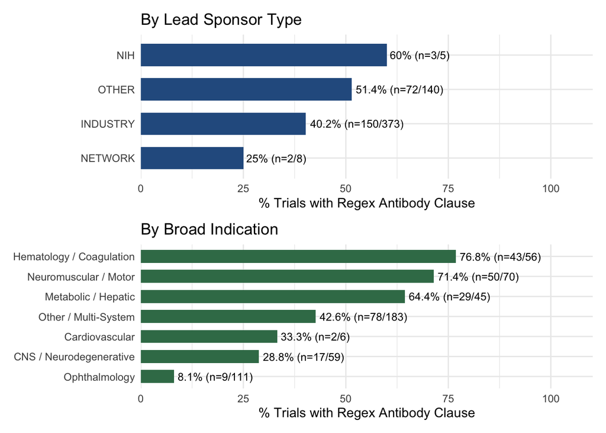

```r
p_sponsor <- sponsor_ab_summary %>%
  filter(n_trials >= 5) %>%
  mutate(sponsor_clean = fct_reorder(sponsor_clean, pct_with_ab)) %>%
  ggplot(aes(x = sponsor_clean, y = pct_with_ab)) +
  geom_col(fill = "#2B5C8F", width = 0.65) +
  geom_text(aes(label = paste0(pct_with_ab, "% (n=", n_with_ab, "/", n_trials, ")")),
            hjust = -0.05, size = 3.2) +
  coord_flip() +
  scale_y_continuous(limits = c(0, 105), expand = expansion(mult = c(0, 0.05))) +
  labs(title = "By Lead Sponsor Type", x = NULL, y = "% Trials with Regex Antibody Clause") +
  theme_minimal(base_size = 11)

p_indication <- indication_ab_summary %>%
  filter(n_trials >= 5) %>%
  mutate(indication_group = fct_reorder(indication_group, pct_with_ab)) %>%
  ggplot(aes(x = indication_group, y = pct_with_ab)) +
  geom_col(fill = "#3B7A57", width = 0.65) +
  geom_text(aes(label = paste0(pct_with_ab, "% (n=", n_with_ab, "/", n_trials, ")")),
            hjust = -0.05, size = 3.2) +
  coord_flip() +
  scale_y_continuous(limits = c(0, 105), expand = expansion(mult = c(0, 0.05))) +
  labs(title = "By Broad Indication", x = NULL, y = "% Trials with Regex Antibody Clause") +
  theme_minimal(base_size = 11)

p_sponsor / p_indication
```

________________________________________________________________________________________

## 4 Results

### 4.1 Regex Pipeline

Within the 272 filtered clauses, 161 clauses (59.2%) explicitly referenced an AAV serotype string and 127 clauses (46.7%) matched a numeric titer or dilution/concentration threshold.

```r
# Combine sponsor and indication summaries into clean reporting tables
knitr::kable(sponsor_ab_summary, digits = 1)
knitr::kable(indication_ab_summary, digits = 1)
```

Table 1: Regex-extracted anti-AAV antibody and numeric titer prevalence across lead sponsor classes and broad therapeutic indications (N = 530 trials).

| sponsor_clean | n_trials | n_with_ab | pct_with_ab | n_with_titer | pct_with_titer_among_ab | median_enrollment |
| --- | --- | --- | --- | --- | --- | --- |
| INDUSTRY | 373 | 150 | 40.2 | 65 | 43.3 | 17.0 |
| OTHER | 140 | 72 | 51.4 | 47 | 65.3 | 9.0 |
| NETWORK | 8 | 2 | 25.0 | 1 | 50.0 | 47.5 |
| NIH | 5 | 3 | 60.0 | 2 | 66.7 | 19.0 |
| OTHER_GOV | 4 | 1 | 25.0 | 0 | 0.0 | 5.5 |

| indication_group | n_trials | n_with_ab | pct_with_ab | n_with_titer | pct_with_titer_among_ab |
| --- | --- | --- | --- | --- | --- |
| Other / Multi-System | 183 | 78 | 42.6 | 43 | 55.1 |
| Ophthalmology | 111 | 9 | 8.1 | 6 | 66.7 |
| Neuromuscular / Motor | 70 | 50 | 71.4 | 30 | 60.0 |
| CNS / Neurodegenerative | 59 | 17 | 28.8 | 10 | 58.8 |
| Hematology / Coagulation | 56 | 43 | 76.8 | 13 | 30.2 |
| Metabolic / Hepatic | 45 | 29 | 64.4 | 12 | 41.4 |
| Cardiovascular | 6 | 2 | 33.3 | 1 | 50.0 |

#### 4.1.1 Variation by Therapeutic Indication and Lead Sponsor Type

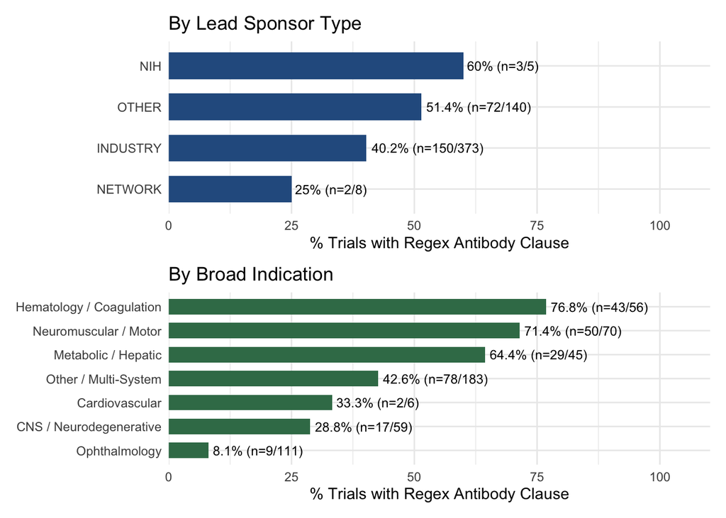

Figure 1: Proportion of interventional AAV trials with regex-matched antibody criteria by lead sponsor class (top) and broad clinical indication (bottom).

```r
# Plot regex antibody clause prevalence across lead sponsors and therapeutic areas
p_sponsor / p_indication
```

#### 4.1.2 Enrollment Year, Trial Era, and Clinical Phase Trends

```r
knitr::kable(era_ab_summary, digits = 1)
knitr::kable(phase_ab_summary, digits = 1)
```

Table 2: Regex-extracted antibody and numeric titer counts by enrollment era and trial phase.

| trial_era | n_trials | n_with_ab | pct_with_ab | n_with_titer |
| --- | --- | --- | --- | --- |
| 2018–2021 | 119 | 47 | 39.5 | 19 |
| 2022–Present | 283 | 122 | 43.1 | 70 |
| Pre-2018 | 128 | 59 | 46.1 | 26 |

| phase_clean | n_trials | n_with_ab | pct_with_ab | n_with_titer |
| --- | --- | --- | --- | --- |
| PHASE1/PHASE2 | 219 | 104 | 47.5 | 52 |
| PHASE1 | 121 | 54 | 44.6 | 26 |
| PHASE3 | 53 | 21 | 39.6 | 7 |
| PHASE2 | 48 | 10 | 20.8 | 3 |
| EARLY_PHASE1 | 44 | 23 | 52.3 | 16 |
| Unspecified / NA | 27 | 9 | 33.3 | 8 |
| PHASE2/PHASE3 | 17 | 6 | 35.3 | 3 |
| PHASE4 | 1 | 1 | 100.0 | 0 |

#### 4.1.3 Limitations and Future Work

Because these findings come from a deterministic `tidyverse` regex baseline (Section 3), a number of caveats apply here. Exact token and pattern matching can miss titer cutoffs written in narrative prose or non-standard formats, serotype assignment can be incomplete when vector names appear outside the matched clause, broad indication grouping leaves **183** trials in `"Other / Multi-System"`, and small subgroup counts (such as `NIH`, $n = 5$, or `PHASE4`, $n = 1$) warrant caution in statistical comparisons. I plan to circle back in future work to benchmark a local, open-weight LLM via `Ollama` and `ellmer` against this regex baseline to evaluate semantic disambiguation of antibody relevance, rule direction/polarity, assay type, and normalized titer thresholds!

________________________________________________________________________________________